# Analyse des communautés fongiques / Fungal communities analysis

Alexis Carteron & Simon Morvan

2018-05-03 13:29:22

#### Pourquoi Phyloseq?

- Pour des raisons pratiques: utilisation simple (une fois que l’objet S4 est assemblé), rapide pour faire graphiques et utiliser les fonctions
- Améliore le partage, le stockage et la reproducibilité
- Actuellement developpé et amélioré par des biostatisticiens (FAQ importante)  
  Mais pas le seul outils à faire cela (e.g.: [Rhea](https://lagkouvardos.github.io/Rhea/) pipeline)

#### Why Phyloseq?

- For practical reasons: Easy to use at first (once you have built the S4 object), quick and nice functions and figures
- Improve sharin, storagre and reproducibility
- Currently being developed and improved by biostatistician (great FAQ)  
  Other great resources are available (e.g.: [Rhea](https://lagkouvardos.github.io/Rhea/) pipeline)

### 1. Commençons! / Let’s start!

#### Charger les librairies / Load packages

```r
library(phyloseq)
library(vegan)
library(ggplot2)
```

R version 3.4.3  
Phyloseq version 1.22.3  
Linux machine image 4.4.0-64-generic

#### Importer les données / Data import

```r
## Sample data
soiltab <- read.table('data/soil.csv', sep = ';', row.names = 1, header = TRUE)

# Taxonomy table
load("data/taxotab.01.05.rdata")

# ASV table
load("data/seqtab.nochim.rdata")
```

#### Construire l’objet Phyloseq / Construct the Phyloseq object

```r
ps <- phyloseq(otu_table(seqtab.nochim, taxa_are_rows=FALSE),
               sample_data(soiltab),
               tax_table(as.matrix(taxo$tax)))
ps
```

```
## phyloseq-class experiment-level object
## otu_table()   OTU Table:         [ 546 taxa and 74 samples ]
## sample_data() Sample Data:       [ 74 samples by 8 sample variables ]
## tax_table()   Taxonomy Table:    [ 546 taxa by 7 taxonomic ranks ]
```

#### Réordonner les facteurs / Reorder factors

```r
sample_data(ps)$horizon = factor(sample_data(ps)$horizon, levels = c('L', 'F', 'H', 'Ae', 'B'))
sample_data(ps)$forest = factor(sample_data(ps)$forest, levels = c('AS', 'Mixed', 'FG'))
```

#### Pour commencer directement avec l’objet Phyloseq / To start directly from Phyloseq object

```r
#load(file = "data/ps.rdata")
#ps
```

### 2. Filtrage et transformation / Filtering and transformation

#### Subset of the dataset with only fungi

```r
ps.fungi = subset_taxa(ps, Kingdom=="k__Fungi")
ntaxa(ps)
```

```
## [1] 546
```

```r
ntaxa(ps.fungi)
```

```
## [1] 524
```

Filtered 22 non-fungal taxa

#### Enlever les taxons avec seulement 1 ou 2 sequences au total / Remove singletons and doubletons

```r
ps.fungi.nosd = filter_taxa(ps.fungi, function(x) sum(x) > 2, TRUE)
ntaxa(ps.fungi.nosd)
```

```
## [1] 523
```

#### Transformation log + 1 pour normaliser les données / Shifted log transformation to normalize

```r
ps.fungi.nosd.log <- transform_sample_counts(ps.fungi.nosd, function(x) log(x+1))
```

#### Agglomerer les taxons au niveau specifique / Agglomerate taxa at the species level

```r
ps.fungi.nosd.log.sp = tax_glom(ps.fungi.nosd.log, "Species", NArm = FALSE) # NArm = FALSE in order to keep ESV not taxonomically assigned at the species level
```

#### Exemple de transmformation / Example of other transformation

```r
ps.fungi.nosd.hel = transform_sample_counts(ps.fungi.nosd, function(x) sqrt(x/sum(x))) # Hellinger transformation
```

### 3. Exploration des données / Data exploration

#### Details de l’objet Phyloseq / Details of the object Phyloseq

```r
ntaxa(ps.fungi.nosd.log)
```

```
## [1] 523
```

```r
nsamples(ps.fungi.nosd.log)
```

```
## [1] 74
```

```r
rank_names(ps.fungi.nosd.log)
```

```
## [1] "Kingdom" "Phylum"  "Class"   "Order"   "Family"  "Genus"   "Species"
```

```r
sample_variables(ps.fungi.nosd.log)
```

```
## [1] "sampleID" "plot"     "block"    "forest"   "horizon"  "Carbon"
## [7] "Nitrogen" "pH"
```

```r
otu_table(ps.fungi.nosd.log)[1:2, 1:2]
```

```
## OTU Table:          [2 taxa and 2 samples]
##                      taxa are columns
##     ATGCGATAAGTAATGTGAATTGCAGAATTCAGTGAATCATCGAATCTTTGAACGCACCTT…
## S10                                                                                                                                                                                                                                                                                                      …
## S11                                                                                                                                                                                                                                                                                                      …
##     ATGCGATACGTAATGTGAATTGCAGAATTCAGTGAATCATCGAATCTTTGAACGCACATT…
## S10                                                                                                                                                                                                                                                                                                      …
## S11                                                                                                                                                                                                                                                                                                      …
```

```r
tax_table(ps.fungi.nosd.log)[1:2, 1:2]
```

```
## Taxonomy Table:     [2 taxa by 2 taxonomic ranks]:
##                                                                                                                                                                                                                                                                                                          …
## ATGCGATAAGTAATGTGAATTGCAGAATTCAGTGAATCATCGAATCTTTGAACGCACCTT… "k__Fungi"
## ATGCGATACGTAATGTGAATTGCAGAATTCAGTGAATCATCGAATCTTTGAACGCACATT…               "k__Fungi"
##                                                                                                                                                                                                                                                                                                          …
## ATGCGATAAGTAATGTGAATTGCAGAATTCAGTGAATCATCGAATCTTTGAACGCACCTT… "p__Basidiomycota"
## ATGCGATACGTAATGTGAATTGCAGAATTCAGTGAATCATCGAATCTTTGAACGCACATT…               "p__Mucoromycota"
```

#### CHALLENGE

> Pouvez-vous trouvez le nombre de phylum de champignons?  
> Can you find the number of fungal phylum?

#### Profondeur de sequencage après filtrage de la canalisation Dada2 / Sequencing depth per samples after filtering of Dada2 pipeline

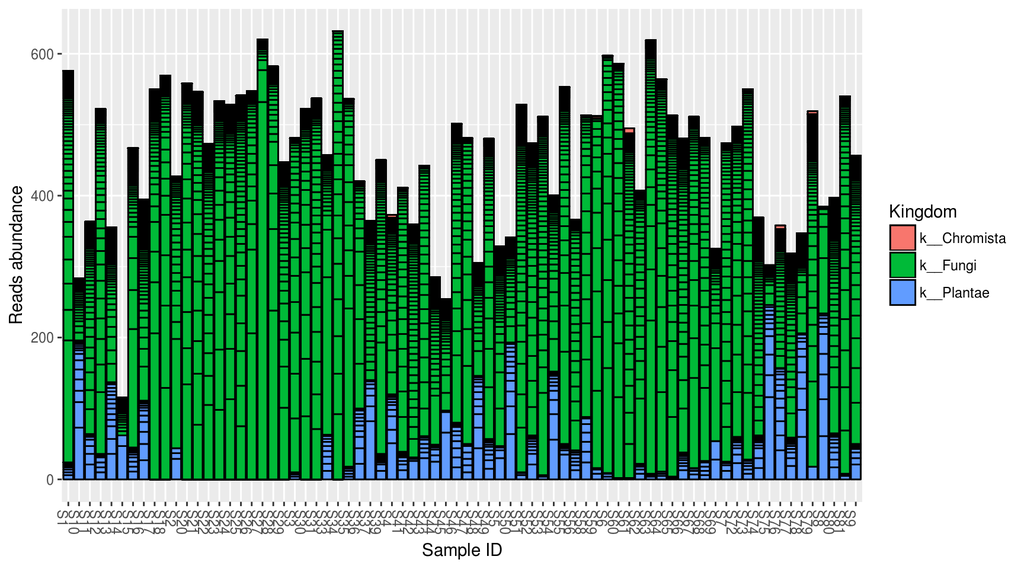

```r
plot_bar(ps, x = "Sample", y = "Abundance", fill = "Kingdom") +
  geom_bar(stat="identity", color = "black") +
  labs(x = "Sample ID", y = "Reads abundance")
```

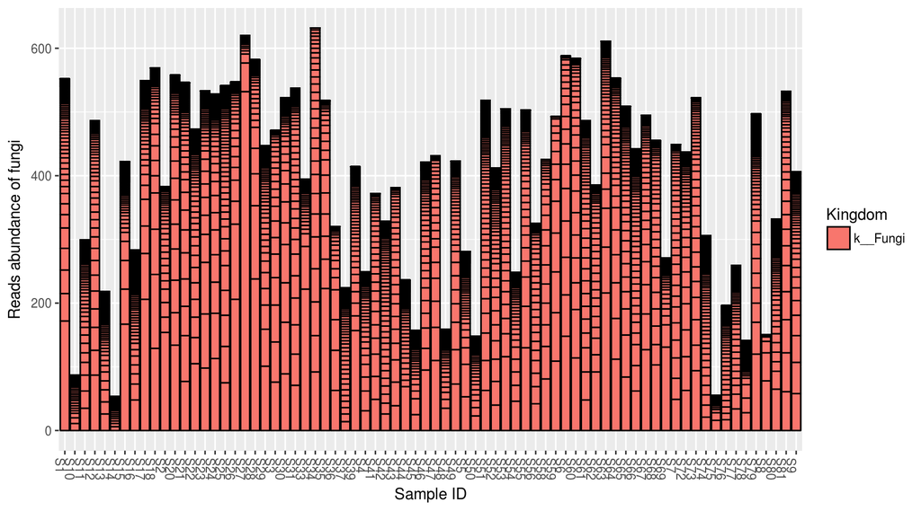

```r
plot_bar(ps.fungi,  x = "Sample", y = "Abundance", fill = "Kingdom") +
  geom_bar(stat="identity", color = "black") +
  labs(x = "Sample ID", y = "Reads abundance of fungi")
```

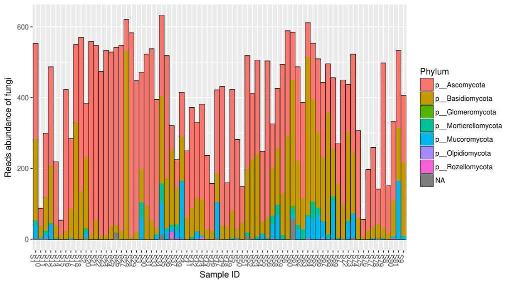

```r
plot_bar(ps.fungi,  x = "Sample", y = "Abundance", fill = "Phylum") +
  geom_bar(stat="identity") +
  labs(x = "Sample ID", y = "Reads abundance of fungi")
```

#### Schéma expérimental / Sampling design

[figure not shown]

**facet_wrap(~forest)**

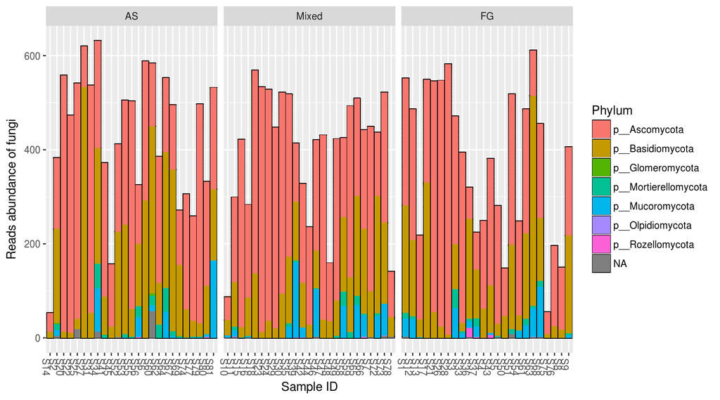

```r
plot_bar(ps.fungi, fill = "Phylum") +
  geom_bar(stat="identity") +
  facet_wrap(~forest, ncol = 3, scales = "free_x") +
  labs(x = "Sample ID", y = "Reads abundance of fungi")
```

**facet_wrap(horizon~forest)**

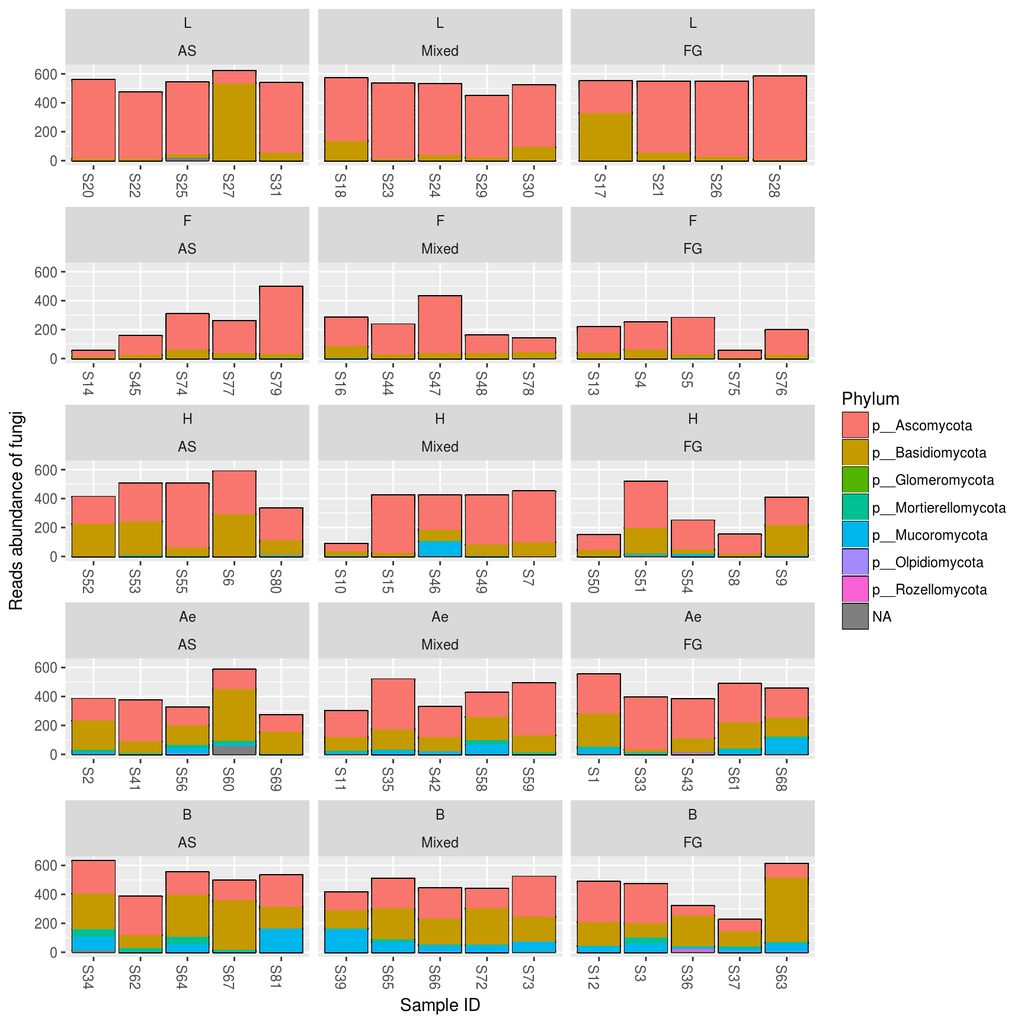

```r
plot_bar(ps.fungi, fill = "Phylum") +
  geom_bar(stat="identity") +
  facet_wrap(horizon~forest, ncol = 3, scales = "free_x") +
  labs(x = "Sample ID", y = "Reads abundance of fungi")
```

### 3. Ordination non contrainte / Unconstrained ordination

#### NMDS avec measure de dissimilarité de Bray-Curtis / NMDS with Bray-Curtis measure dissimilarity (aka Steinhaus)

```r
ord.nmds.bray <- ordinate(ps.fungi.nosd.log.sp, method="NMDS", k = 2, try = 20, distance = "bray") # /!\ number of tries need to be high enough to reach convergence
```

```
## Wisconsin double standardization
## *** No convergence -- monoMDS stopping criteria:
##     20: stress ratio > sratmax
```

#### Figure rapide / Quick plot

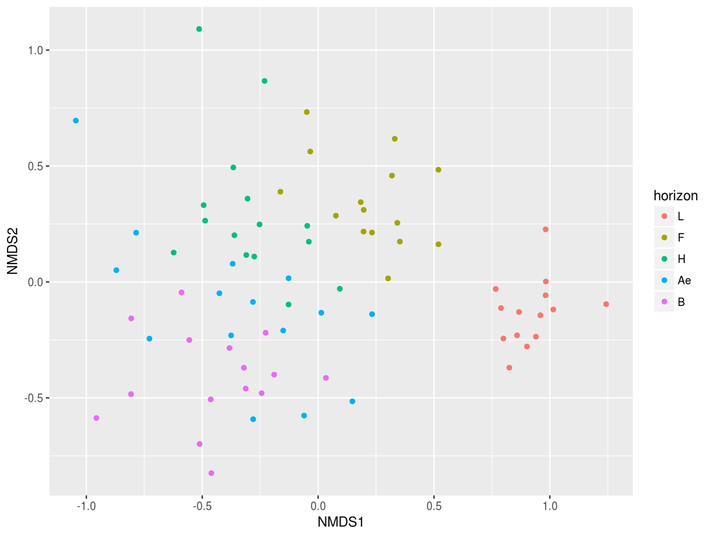

```r
plot_ordination(ps.fungi.nosd.log.sp, ord.nmds.bray, type="samples", color = "horizon")
```

#### Figure detaillée / Full plot

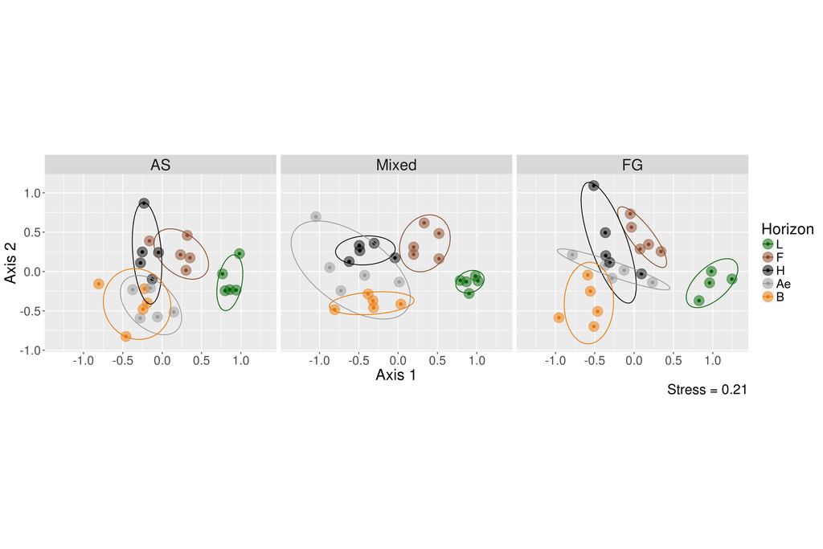

```r
plot_ordination(ps.fungi.nosd.log.sp, ord.nmds.bray, type="samples", color = "horizon") +
  geom_point(size = 6, alpha = .5, show.legend = TRUE) +
  scale_color_manual(name = "Horizon", values = c('darkgreen', 'sienna4', 'grey1', 'grey60', 'darkorange2')) +
  labs(x = "Axis 1", y = "Axis 2", caption = paste("Stress =", round(ord.nmds.bray$stress, 2))) +
  facet_wrap(~forest) +
  stat_ellipse(type = "t", level = 0.8) + # 80% confidence interval ellispes
  coord_fixed() +
  theme(text = element_text(size=20), strip.text = element_text(size=20))
```

#### NMDS avec les données binaire / NMDS with binary data

```r
ord.nmds.bin <- ordinate(ps.fungi.nosd.log.sp, method="NMDS", k = 2, try = 20, distance = "bray", binary =TRUE)
```

```
## Wisconsin double standardization
## *** No convergence -- monoMDS stopping criteria:
##     20: stress ratio > sratmax
```

#### Figure de la NMDS avec données binaires / NMDS plot with binary data

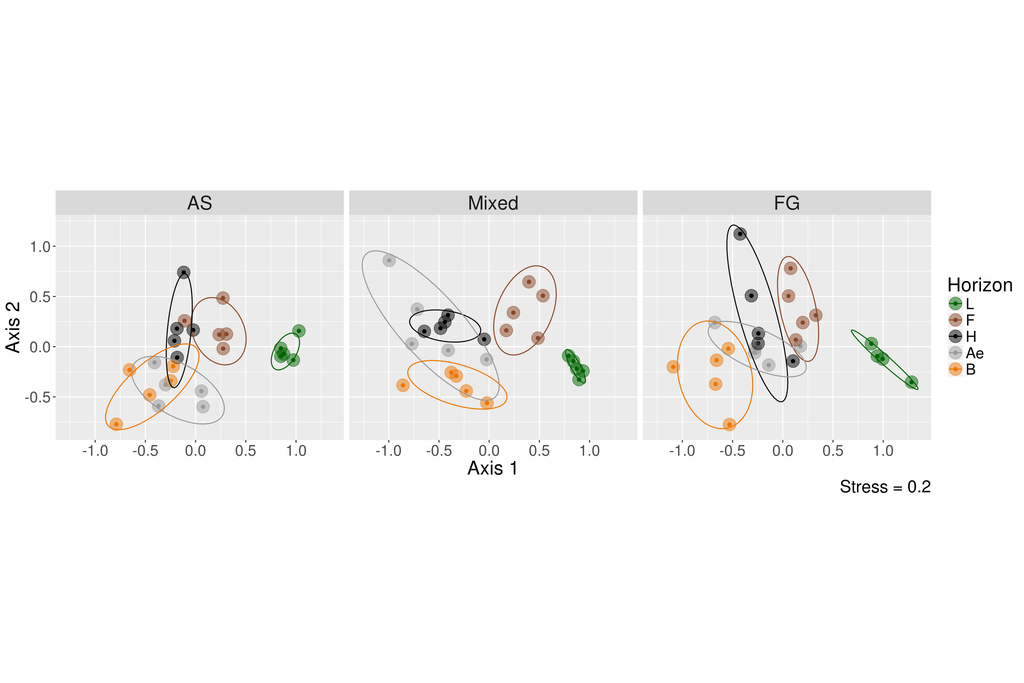

```r
plot_ordination(ps.fungi.nosd.log.sp, ord.nmds.bin, type="samples", color = "horizon") +
  geom_point(size = 6, alpha = .5, show.legend = TRUE) +
  scale_color_manual(name = "Horizon", values = c('darkgreen', 'sienna4', 'grey1', 'grey60', 'darkorange2')) +
  labs(x = "Axis 1", y = "Axis 2", caption = paste("Stress =", round(ord.nmds.bin$stress, 2))) +
  facet_wrap(~forest) +
  stat_ellipse(type = "t", level = 0.8) + # 80% confidence interval ellispes
  coord_fixed() +
  theme(text = element_text(size=20), strip.text = element_text(size=20))
```

#### CHALLENGE

> Pouvez-vous faire une analyse en composantes principales?  
> Can you run a principal component analysis?

### 4. Analyse de variance: les communautés sont-elles statistiquement differentes? / Variance analysis: Are communities statistically different?

```r
metadata <- as(sample_data(ps.fungi.nosd.log.sp), "data.frame") # Export data
```

#### PERMANOVA avec la measure de Bray-Curtis / PERMANOVA with Bray-Curtis measure

```r
adonis(phyloseq::distance(physeq = ps.fungi.nosd.log.sp, method="bray") ~ horizon * forest, strata = metadata$block,# Horizon and forest effect with interaction and block as strata
      data = metadata,
      permutations = 99999)
```

```
##
## Call:
## adonis(formula = phyloseq::distance(physeq = ps.fungi.nosd.log.sp,      method = "bray") ~ horizon * forest, data = metadata, permutations = 99999,      strata = metadata$block)
##
## Blocks:  strata
## Permutation: free
## Number of permutations: 99999
##
## Terms added sequentially (first to last)
##
##                Df SumsOfSqs MeanSqs F.Model      R2  Pr(>F)
## horizon         4    6.8294 1.70736  7.6311 0.29952   1e-05 ***
## forest          2    0.9236 0.46181  2.0641 0.04051 0.00216 **
## horizon:forest  8    1.8480 0.23099  1.0324 0.08105 0.38681
## Residuals      59   13.2005 0.22374         0.57893
## Total          73   22.8015                 1.00000
## ---
## Signif. codes:  0 '***' 0.001 '**' 0.01 '*' 0.05 '.' 0.1 ' ' 1
```

#### Test de l’homogénéité de dispersion / Test for the homogeneity of dispersion

```r
betadisp <- betadisper(phyloseq::distance(physeq = ps.fungi.nosd.log.sp, method="bray"), metadata$forest)
permutest(betadisp, permutations = 99999)
```

```
##
## Permutation test for homogeneity of multivariate dispersions
## Permutation: free
## Number of permutations: 99999
##
## Response: Distances
##           Df  Sum Sq   Mean Sq      F N.Perm Pr(>F)
## Groups     2 0.00882 0.0044116 0.9854  99999 0.3799
## Residuals 71 0.31786 0.0044769
```

```r
betadisp <- betadisper(phyloseq::distance(physeq = ps.fungi.nosd.log.sp, method="bray"), metadata$horizon)
permutest(betadisp, permutations = 99999)
```

```
##
## Permutation test for homogeneity of multivariate dispersions
## Permutation: free
## Number of permutations: 99999
##
## Response: Distances
##           Df  Sum Sq Mean Sq      F N.Perm  Pr(>F)
## Groups     4 0.13844 0.03461 5.1657  99999 0.00123 **
## Residuals 69 0.46229 0.00670
## ---
## Signif. codes:  0 '***' 0.001 '**' 0.01 '*' 0.05 '.' 0.1 ' ' 1
```

#### PERMANOVA avec les données binaires / PERMANOVA with binary data

```r
adonis(phyloseq::distance(ps.fungi.nosd.log.sp, method="bray", binary = TRUE) ~ horizon * forest, strata = metadata$block, # Horizon and forest effect with interaction and block as strata
       data = metadata,
       permutations = 99999)
```

```
##
## Call:
## adonis(formula = phyloseq::distance(ps.fungi.nosd.log.sp, method = "bray",      binary = TRUE) ~ horizon * forest, data = metadata, permutations = 99999,      strata = metadata$block)
##
## Blocks:  strata
## Permutation: free
## Number of permutations: 99999
##
## Terms added sequentially (first to last)
##
##                Df SumsOfSqs MeanSqs F.Model      R2  Pr(>F)
## horizon         4    6.8302 1.70756  8.8627 0.33451   1e-05 ***
## forest          2    0.7049 0.35247  1.8294 0.03452 0.01524 *
## horizon:forest  8    1.5161 0.18951  0.9836 0.07425 0.53206
## Residuals      59   11.3674 0.19267         0.55672
## Total          73   20.4186                 1.00000
## ---
## Signif. codes:  0 '***' 0.001 '**' 0.01 '*' 0.05 '.' 0.1 ' ' 1
```

#### Test de l’homogénéité de dispersion / Test for the homogeneity of dispersion

```r
betadisp <- betadisper(phyloseq::distance(ps.fungi.nosd.log.sp, method="bray", binary = TRUE), metadata$forest)
permutest(betadisp, permutations = 99999)
```

```
##
## Permutation test for homogeneity of multivariate dispersions
## Permutation: free
## Number of permutations: 99999
##
## Response: Distances
##           Df  Sum Sq   Mean Sq      F N.Perm Pr(>F)
## Groups     2 0.00669 0.0033460 0.5549  99999 0.5757
## Residuals 71 0.42809 0.0060294
```

```r
betadisp <- betadisper(phyloseq::distance(ps.fungi.nosd.log.sp, method="bray", binary = TRUE), metadata$horizon)
permutest(betadisp, permutations = 99999)
```

```
##
## Permutation test for homogeneity of multivariate dispersions
## Permutation: free
## Number of permutations: 99999
##
## Response: Distances
##           Df  Sum Sq  Mean Sq      F N.Perm  Pr(>F)
## Groups     4 0.17097 0.042743 6.5332  99999 0.00022 ***
## Residuals 69 0.45143 0.006542
## ---
## Signif. codes:  0 '***' 0.001 '**' 0.01 '*' 0.05 '.' 0.1 ' ' 1
```

### 5. Ordination sous contraites: analyse de redondance / Constrained ordination: Redundancy Analysis (RDA)

```r
ord.rda <- ordinate(ps.fungi.nosd.log.sp, formula = ps.fungi.nosd.log.sp ~ Carbon+Nitrogen+pH, method="CAP", distance = "bray") # Uses Capscale function of Vegan package
```

#### Obtenir les statistiques de la RDA / RDA stats

```r
RsquareAdj(ord.rda)
```

```
## $r.squared
## [1] 0.2387887
##
## $adj.r.squared
## [1] 0.2061653
```

```r
anova.cca(ord.rda)
```

```
## Permutation test for capscale under reduced model
## Permutation: free
## Number of permutations: 999
##
## Model: capscale(formula = OTU ~ Carbon + Nitrogen + pH, data = data, distance = distance)
##          Df SumOfSqs      F Pr(>F)
## Model     3   5.4447 7.1209  0.001 ***
## Residual 70  17.8409
## ---
## Signif. codes:  0 '***' 0.001 '**' 0.01 '*' 0.05 '.' 0.1 ' ' 1
```

#### Verifications des facteurs d’inflation de la variance / Check variance inflation factors (VIF)

```r
vif.cca(ord.rda) # VIF < 10 should be fine
```

```
##   Carbon Nitrogen       pH
## 6.975395 7.163518 1.129545
```

#### CHALLENGE

> Que feriez-vous pour exclure les données d’azote de la RDA?  
> What if you want to exclude Nitrogen data of the RDA?

#### Figure rapide / Quick plot

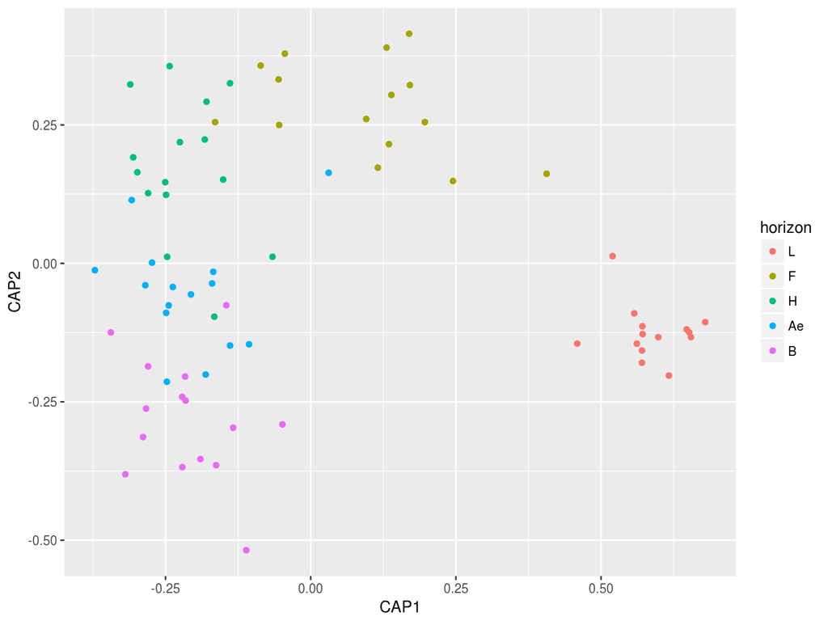

```r
plot_ordination(ps.fungi.nosd.log.sp, vegan::scores(ord.rda, scaling=1), type="sites",  color = "horizon")
```

#### Enregistrer les valeurs propres / Get eigenvector values

```r
evals <- ord.rda$CCA$eig/sum(ord.rda$CCA$eig)
```

#### Figure detaillée / Full plot

```r
arrowmat = vegan::scores(ord.rda, display = "bp", scaling = 1) # Add the environmental variables as arrows
arrowdf <- data.frame(arrowmat) # Add labels
rownames(arrowdf) <- c("Carbon","Nitrogen","pH") # Add rownames
arrowdf <- data.frame(labels = c("Carbon","Nitrogen","pH"), arrowmat) # Make a data.frame
```

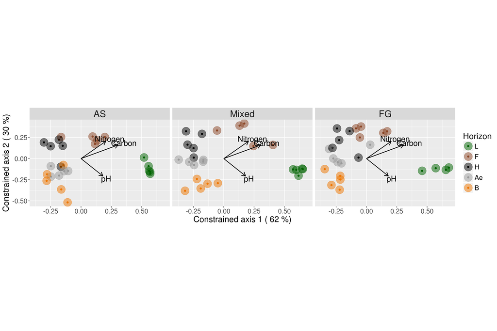

```r
plot_ordination(ps.fungi.nosd.log.sp, vegan::scores(ord.rda, scaling = 1), type="sites",  color = "horizon") +
  coord_fixed(sqrt(evals[2] / evals[1])) +
  geom_point(size = 8, alpha = .5) +
  scale_color_manual(name = "Horizon", values = c('darkgreen', 'sienna4', 'grey1', 'grey60', 'darkorange2')) +
  geom_segment(aes(xend = CAP1, yend = CAP2, x = 0, y = 0), size = .7, data = arrowdf, color = "black", arrow = arrow(length = unit(0.05, "npc"))) +
  geom_text(aes(x = CAP1*1.15, y = CAP2*1.15, color = NULL, label = labels), size = 6, data = arrowdf, show.legend = FALSE) +
  facet_wrap(~forest) +
  theme(text = element_text(size=18), strip.text = element_text(size=20)) +
  labs(x = paste("Constrained axis 1 (",round(evals[1]*100, 0),"%)"), y = paste("Constrained axis 2 (",round(evals[2]*100, 0),"%)"))
```